# Is 6813 Spring 2026

Mar 10, 2026

## 1 Introduction

MasterControl is a leading provider of quality and manufacturing management software for life sciences organizations, including pharmaceutical, biotechnology, and medical device manufacturers. Its established Quality Solutions (Qx) product line achieves a strong conversion rate of 19.7%, the newer Manufacturing Solutions (Mx) line is converting at only 12.7%. This performance gap represents both a revenue opportunity and a strategic concern as the company seeks to expand Mx adoption across existing and new markets.

Qx benefits from stronger brand recognition and market maturity; Mx is still in a growth phase. As a result, MasterControl lacks clear visibility into which customer segments are most likely to convert for this product.

This project will apply exploratory data analysis to identify the characteristics most strongly associated with Mx conversion. Specifically, we will evaluate how industry, manufacturing model, company tier, geography, and job role influence progression to high-value sales stages (SQL, SQO, or WON). The ultimate goal is to develop actionable insights and a ranked lead-scoring framework that enables MasterControl to prioritize high-potential prospects, define MasterControls ideal customer profile for the MX solution, and improve overall Mx conversion performance.

```r
library(tidyverse)
library(lubridate)
library(janitor)
library(skimr)
```

Exploratory Data Analysis Summary view The initial exploratory analysis, using functions like str(), glimpse(), and skim(), was conducted to evaluate the structure of the dataset, variable types, completeness, and overall data quality. This early inspection will help to guide the subsequent feature engineering and data preparation steps necessary for modeling.

Key dataset details include:

14 original features

Most columns had very little missing data, with the notable exception of the contact_lead_title field. We will take a look at that and determine what should be done with missing data in that field.

Identifiers: QAL.ID and contact.lead.id

## 2 Loading in and initial exploration

```r
# import file   #QAL_Performance_for_MSBA.csv
#Mastercontrol QAL Performance-2.csv
qal <- read_csv("Mastercontrol QAL Performance-2.csv")
glimpse(qal)
```

```
## Rows: 16,644
## Columns: 14
## $ `acct primary site function`   <chr> "Food and beverage", "Surgical instrume…
## $ `acct manufacturing model`     <chr> "Consumer Packaged Goods", "In-House", …
## $ `acct target industry`         <chr> "Non-Life Science", "Medical Device", "…
## $ `contact/lead title`           <chr> "QA Manager", "Quality Manager", "ING",…
## $ `QAL ID`                       <chr> "a0dPQ000005WbfuYAC", "a0dPQ00000CRpkLY…
## $ `contact/lead id`              <chr> "0030c00002XPeNGAA1", "0030c00002ZaC9pA…
## $ next_stage__c                  <chr> "SQL", "Won", "Recycled", "Recycled", "…
## $ Priority                       <chr> "P1 - Webinar Demo", "Priority 2", "Pri…
## $ `acct territory rollup`        <chr> "Americas", "Americas", "EMEA", "Americ…
## $ `acct tier rollup`             <chr> "Medium", "Medium", "Large", "Medium", …
## $ solution                       <chr> "Mx", "Mx", "Qx", "Logbooks", "Qx", "Qx…
## $ solution_rollup                <chr> "Mx", "Mx", "Qx", "Mx", "Qx", "Qx", "Qx…
## $ `last tactic campaign channel` <chr> "Online Ads", "SEO", "Email", "External…
## $ `qal cohort date`              <date> 2025-06-16, 2025-11-13, 2024-02-15, 20…
```

```r
head(qal)
```

```
## # A tibble: 6 × 14
##   `acct primary site function`   acct manufacturing mod…¹ `acct target industry`
##   <chr>                          <chr>                    <chr>
## 1 Food and beverage              Consumer Packaged Goods  Non-Life Science
## 2 Surgical instruments           In-House                 Medical Device
## 3 Cell therapies (CAR-T, NK)     Hospital Investigationa… Blood & Biologics
## 4 In-vitro diagnostic (IVD) kits In-House                 Medical Device
## 5 Nutraceutical manufacturing    CMO                      Pharma & BioTech
## 6 Diagnostic Equipment           In-House                 Medical Device
## # ℹ abbreviated name: ¹`acct manufacturing model`
## # ℹ 11 more variables: `contact/lead title` <chr>, `QAL ID` <chr>,
## #   `contact/lead id` <chr>, next_stage__c <chr>, Priority <chr>,
## #   `acct territory rollup` <chr>, `acct tier rollup` <chr>, solution <chr>,
## #   solution_rollup <chr>, `last tactic campaign channel` <chr>,
## #   `qal cohort date` <date>
```

### 2.1 clean up feature names

```r
# clean up feature names
qal <- qal %>% clean_names()
names(qal)
```

```
##  [1] "acct_primary_site_function"   "acct_manufacturing_model"
##  [3] "acct_target_industry"         "contact_lead_title"
##  [5] "qal_id"                       "contact_lead_id"
##  [7] "next_stage_c"                 "priority"
##  [9] "acct_territory_rollup"        "acct_tier_rollup"
## [11] "solution"                     "solution_rollup"
## [13] "last_tactic_campaign_channel" "qal_cohort_date"
```

```r
# Summary of qal dataset
skim(qal)
```

Data summary

| Name | qal |
| --- | --- |
| Number of rows | 16644 |
| Number of columns | 14 |
| _______________________ |  |
| Column type frequency: |  |
| character | 13 |
| Date | 1 |
| ________________________ |  |
| Group variables | None |

**Variable type: character**

| skim_variable | n_missing | complete_rate | min | max | empty | n_unique | whitespace |
| --- | --- | --- | --- | --- | --- | --- | --- |
| acct_primary_site_function | 60 | 1.00 | 6 | 42 | 0 | 79 | 0 |
| acct_manufacturing_model | 101 | 0.99 | 3 | 34 | 0 | 19 | 0 |
| acct_target_industry | 45 | 1.00 | 7 | 17 | 0 | 5 | 0 |
| contact_lead_title | 4861 | 0.71 | 2 | 125 | 0 | 6588 | 0 |
| qal_id | 0 | 1.00 | 18 | 18 | 0 | 16644 | 0 |
| contact_lead_id | 3 | 1.00 | 18 | 18 | 0 | 15371 | 0 |
| next_stage_c | 394 | 0.98 | 3 | 8 | 0 | 8 | 0 |
| priority | 0 | 1.00 | 5 | 20 | 0 | 11 | 0 |
| acct_territory_rollup | 132 | 0.99 | 4 | 14 | 0 | 6 | 0 |
| acct_tier_rollup | 45 | 1.00 | 5 | 6 | 0 | 4 | 0 |
| solution | 0 | 1.00 | 2 | 19 | 0 | 12 | 0 |
| solution_rollup | 0 | 1.00 | 2 | 2 | 0 | 2 | 0 |
| last_tactic_campaign_channel | 0 | 1.00 | 3 | 20 | 0 | 12 | 0 |

**Variable type: Date**

| skim_variable | n_missing | complete_rate | min | max | median | n_unique |
| --- | --- | --- | --- | --- | --- | --- |
| qal_cohort_date | 0 | 1 | 2024-01-01 | 2025-12-31 | 2024-11-27 | 595 |

## 3 Explore and visualize missingness patterns in the dataset

```r
# creates a table of missing values for every column in qal, calculates the percentage missing, and then sorts columns from most missing to least missing
qal %>%
  summarise(across(everything(), ~sum(is.na(.)))) %>%
  pivot_longer(everything(), names_to = "column", values_to = "missing") %>%
  mutate(
    pct_missing = round(missing / nrow(qal) * 100, 2)
  ) %>%
  arrange(desc(pct_missing))
```

```
## # A tibble: 14 × 3
##    column                       missing pct_missing
##    <chr>                          <int>       <dbl>
##  1 contact_lead_title              4861       29.2
##  2 next_stage_c                     394        2.37
##  3 acct_territory_rollup            132        0.79
##  4 acct_manufacturing_model         101        0.61
##  5 acct_primary_site_function        60        0.36
##  6 acct_target_industry              45        0.27
##  7 acct_tier_rollup                  45        0.27
##  8 contact_lead_id                    3        0.02
##  9 qal_id                             0        0
## 10 priority                           0        0
## 11 solution                           0        0
## 12 solution_rollup                    0        0
## 13 last_tactic_campaign_channel       0        0
## 14 qal_cohort_date                    0        0
```

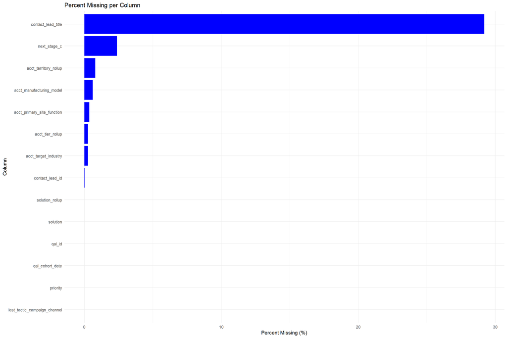

```r
# visualize missingness patterns in the dataset
library(dplyr)
library(tidyr)
library(ggplot2)

qal %>%
  summarise(across(everything(), ~ sum(is.na(.)))) %>%
  pivot_longer(everything(),
               names_to = "column",
               values_to = "missing") %>%
  mutate(pct_missing = round(missing / nrow(qal) * 100, 2)) %>%
  arrange(desc(pct_missing)) %>%
  ggplot(aes(x = reorder(column, pct_missing), y = pct_missing)) +
  geom_col(fill = "blue") +
  coord_flip() +
  labs(
    title = "Percent Missing per Column",
    x = "Column",
    y = "Percent Missing (%)"
  ) +
  theme_minimal()
```

The feature with the greatest missingness is contact_lead_title with 29.21%. This missingness is worth exploring.

The Missing Values in next_stage_c are 394 records (2.37%) that represent leads still being evaluated and should be removed.

### 3.1 Further exploration of missingness to check whether the lead reached SQL/SQO/Won in contact_lead_title

```r
# Create a missingness flag for contact_lead_title
library(dplyr)
library(stringr)

qal2 <- qal %>%
  mutate(
    contact_lead_title = str_trim(contact_lead_title),
    title_missing = if_else(
      is.na(contact_lead_title) | contact_lead_title == "",
      "Missing",
      "Not Missing"
    ),
    progressed = if_else(next_stage_c %in% c("SQL", "SQO", "Won"), 1, 0)
  )
```

```r
library(dplyr)

qal2 <- qal %>%
  mutate(
    # Only treat TRUE NA as missing
    title_missing = if_else(is.na(contact_lead_title), "Missing", "Not Missing"),

    # Binary progression variable (using correct column name)
    progressed = if_else(next_stage_c %in% c("SQL", "SQO", "Won"), 1, 0)
  )
```

```r
title_missing_summary <- qal2 %>%
  group_by(title_missing) %>%
  summarise(
    n = n(),
    progressed_n = sum(progressed, na.rm = TRUE),
    progression_rate = progressed_n / n
  ) %>%
  mutate(
    pct_of_total = n / sum(n)   # percentage of missing vs non-missing
  ) %>%
  arrange(desc(progression_rate))

title_missing_summary
```

```
## # A tibble: 2 × 5
##   title_missing     n progressed_n progression_rate pct_of_total
##   <chr>         <int>        <dbl>            <dbl>        <dbl>
## 1 Not Missing   11783         2497            0.212        0.708
## 2 Missing        4861          491            0.101        0.292
```

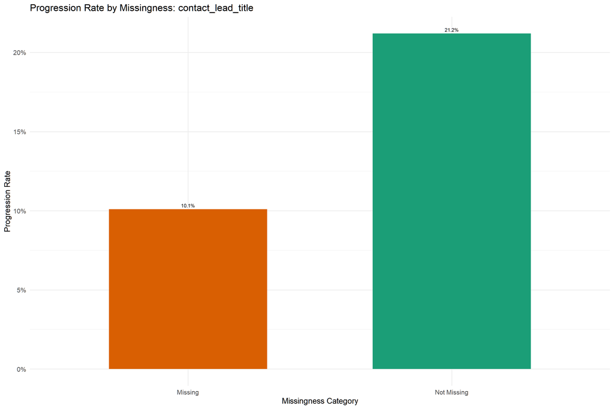

```r
library(ggplot2)

ggplot(title_missing_summary, aes(
  x = reorder(title_missing, progression_rate),
  y = progression_rate,
  fill = title_missing
)) +
  geom_col(width = 0.6) +
  geom_text(aes(label = scales::percent(progression_rate, accuracy = 0.1)),
            vjust = -0.5, size = 3) +
  scale_y_continuous(labels = scales::percent_format()) +
  scale_fill_manual(values = c("Missing" = "#d95f02", "Not Missing" = "#1b9e77")) +
  labs(
    title = "Progression Rate by Missingness: contact_lead_title",
    x = "Missingness Category",
    y = "Progression Rate"
  ) +
  theme_minimal(base_size = 14) +
  theme(legend.position = "none")
```

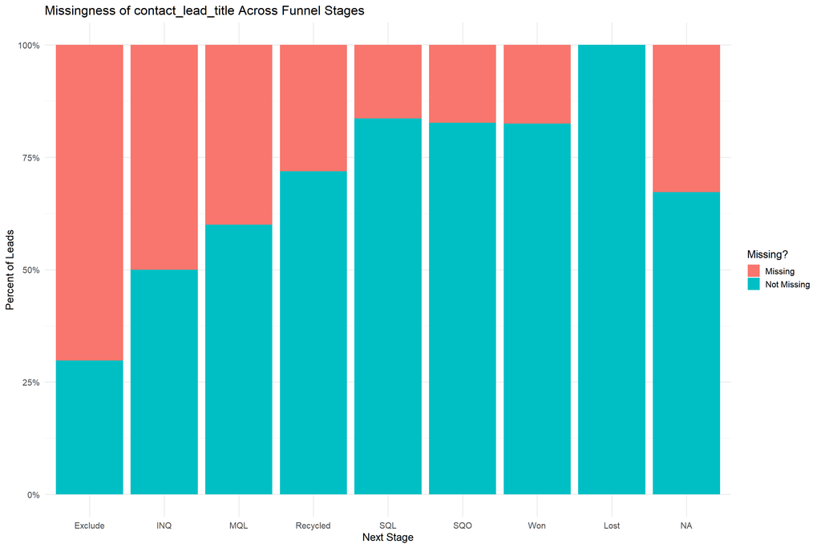

```r
missing_by_stage <- qal2 %>%
  group_by(next_stage_c, title_missing) %>%
  summarise(n = n(), .groups = "drop") %>%
  group_by(next_stage_c) %>%
  mutate(pct = n / sum(n))

ggplot(missing_by_stage, aes(
  x = reorder(next_stage_c, pct),
  y = pct,
  fill = title_missing
)) +
  geom_col(position = "fill") +
  scale_y_continuous(labels = scales::percent_format()) +
  labs(
    title = "Missingness of contact_lead_title Across Funnel Stages",
    x = "Next Stage",
    y = "Percent of Leads",
    fill = "Missing?"
  ) +
  theme_minimal(base_size = 14)
```

Now, there’s a pattern of the least missingness in the latter funnel funnel stages for SQL, SQO and Won. The beginning funnel stages have much higher missingness. The conclusion here is that this missingness is systematic, not random.

From the document, the missing Values are 60 (0.36%) for the acct_primary_site_function, which is very little. However, the effective missingness may be much larger. The document’s AI prompt found “Not Enough Info Found: 2,550 (15.3%). This means the system could not determine what the company manufactures. Mx product is a manufacturing execution product. So this account may not be a good Mx prospect. Likewise, the “Non-manufacturing organization: 5,525 (33.2%)” account may not also be good target for the Mx product.

These two accounts are critical for identifying which types of facilities are best Mx prospects. Missingness is informative and should be treated as its own category.

Similarly, the exploration of the data provided in the acct manufacturing model - Business Model, suggests that the category “Not Enough Info Found” was 2,425 (14.6%). This suggests that the system could not determine the type of manufacturing model for 14.6% of the leads. This category should be treated as a category of missingness that may be systematic and not random.

Both acct manufacturing model and acct_primary_site_function are worth further exploration.